# 代数計算で誤差伝搬を計算する。

`BasicAlgebraicCalculationClass`を継承した自作代数計算クラス`ErrorPropagationClass`使って、誤差伝搬の代数計算を行ったのちに誤差を見積もってみます。

また描画するためのライブラリを使って計算結果の可視化を行ってみます。

`BasicAlgebraicCalculationClass`については別の場所で説明したので省略します。

まずは必要なライブラリをimportしてきます。

```python
from fumi_python_libraries import ErrorPropagationClass
import matplotlib.pyplot as plt
import numpy
import sympy
```

## 使い方

まず誤差伝搬をしたい関数と変数を定義します。

この記法は`BasicAlgebraicCalculationClass`と全く一緒です。

```python
err_pro = ErrorPropagationClass()
var = err_pro.create_variables( ["\\alpha","\\beta"] )
fun = sympy.sqrt( var[0] / var[1] )
err_pro.set_left_hand_side( 'f(\\alpha, \\beta)' )
err_pro.set_right_hand_side( fun )
err_pro.set_variable_symbols()
err_pro.print_formula()
```

$\displaystyle f(\alpha, \beta) = \sqrt{\frac{\alpha}{\beta}}$

`set_variable_symbols()`は引数で変数のリストを渡しますが、何も与えない場合は直近で`create_variables()`で宣言した変数が登録されます。

`partial_derivative( bool )`で登録した代数を変数として、それぞれの誤差伝搬を計算します。

引数は結果を出力するかを選択できます。

loop処理の中でこのような計算をする場合、出力したくないので選べるようになっています。

```python
err_pro.partial_derivative( True )
```

$\displaystyle {\delta}f=\sqrt{\sum_{i=0}^{n} \left( \frac{{\partial} f}{{\partial} x_i} {\delta}x_i \right)^2}$

$\displaystyle x_0 = \alpha$

$\displaystyle x_1 = \beta$

$\displaystyle \frac{\partial f(\alpha, \beta) }{ \partial \alpha } = \frac{\sqrt{\frac{\alpha}{\beta}}}{2 \alpha}$

$\displaystyle \frac{\partial f(\alpha, \beta) }{ \partial \beta } = - \frac{\sqrt{\frac{\alpha}{\beta}}}{2 \beta}$

今回の場合$\alpha$, $\beta$が測定量です。

例えば以下のような精度で測定できたとしましょう。

$$\alpha = 17120 \pm \sqrt{17120} $$ $$\beta = 18571 \pm \sqrt{18571}　$$

測定量の設定と誤差の設定はそれぞれ`set_value_series( value list )`と`set_error_series( error list )`で渡すことができます。

そして、`calculate_erorr( bool, round digit )`で誤差伝搬を計算し、丸めて出力してくれます。

```python
val = [17120., 18571.]
err = [numpy.sqrt(x) for x in val]
err_pro.set_value_series( val )
err_pro.set_error_series( err )
result = err_pro.calculate_erorr( True, 6 )
```

$\displaystyle f(\alpha, \beta) \pm \delta f(\alpha, \beta) = 0.960139 \pm 0.005086$

## 応用例

### Woods–Saxon Potentialとその微分を計算し、誤差つきで描画してみる。

少し高級な例を計算してみます。

まずWoods–Saxon Potentialを定義してみましょう。

```python
err_pro = ErrorPropagationClass()
var = err_pro.create_variables( ["r","R_i","a_i"] )
fun = 1 / ( 1 + sympy.exp( ( var[0] - var[1] ) / var[2] ) )
err_pro.set_left_hand_side( 'f(r, R_i, a_i)' )
err_pro.set_right_hand_side( fun )
err_pro.set_variable_symbols()
err_pro.print_formula()
```

$\displaystyle f(r, R_i, a_i) = \frac{1}{e^{\frac{- R_{i} + r}{a_{i}}} + 1}$

標準的な原子核の教科書では分母の順番は逆になっている気がしますが、これはsympyが勝手に並べ替えています。

並べ直さない方法があると助かるのですが…

そして誤差伝搬を計算します。

ここでは$r_i$, $R_i$, $a_i$全ての要素の誤差伝搬を考えます。

結果は以下のとおりです。

```python
dum = err_pro.partial_derivative( True )
```

$\displaystyle {\delta}f=\sqrt{\sum_{i=0}^{n} \left( \frac{{\partial} f}{{\partial} x_i} {\delta}x_i \right)^2}$

$\displaystyle x_0 = r$

$\displaystyle x_1 = R_i$

$\displaystyle x_2 = a_i$

$\displaystyle \frac{\partial f(r, R_i, a_i) }{ \partial r } = - \frac{e^{\frac{- R_{i} + r}{a_{i}}}}{a_{i} \left(e^{\frac{- R_{i} + r}{a_{i}}} + 1\right)^{2}}$

$\displaystyle \frac{\partial f(r, R_i, a_i) }{ \partial R_i } = \frac{e^{\frac{- R_{i} + r}{a_{i}}}}{a_{i} \left(e^{\frac{- R_{i} + r}{a_{i}}} + 1\right)^{2}}$

$\displaystyle \frac{\partial f(r, R_i, a_i) }{ \partial a_i } = \frac{\left(- R_{i} + r\right) e^{\frac{- R_{i} + r}{a_{i}}}}{a_{i}^{2} \left(e^{\frac{- R_{i} + r}{a_{i}}} + 1\right)^{2}}$

さて次にWoods Saxonの微分を計算してみます。

```python
dif_err_pro = err_pro.copy_class()
func = dif_err_pro.differentiate( 'r' , True )
dif_err_pro.print_formula()
```

$\displaystyle \frac{d}{dr}f(r, R_i, a_i) = - \frac{e^{\frac{- R_{i} + r}{a_{i}}}}{a_{i} \left(e^{\frac{- R_{i} + r}{a_{i}}} + 1\right)^{2}}$

その時の誤差伝搬は以下のとおりです。

```python
dum = dif_err_pro.partial_derivative( True )
```

$\displaystyle {\delta}f=\sqrt{\sum_{i=0}^{n} \left( \frac{{\partial} f}{{\partial} x_i} {\delta}x_i \right)^2}$

$\displaystyle x_0 = r$

$\displaystyle x_1 = R_i$

$\displaystyle x_2 = a_i$

$\displaystyle \frac{\partial \frac{d}{dr}f(r, R_i, a_i) }{ \partial r } = - \frac{e^{\frac{- R_{i} + r}{a_{i}}}}{a_{i}^{2} \left(e^{\frac{- R_{i} + r}{a_{i}}} + 1\right)^{2}} + \frac{2 e^{\frac{2 \left(- R_{i} + r\right)}{a_{i}}}}{a_{i}^{2} \left(e^{\frac{- R_{i} + r}{a_{i}}} + 1\right)^{3}}$

$\displaystyle \frac{\partial \frac{d}{dr}f(r, R_i, a_i) }{ \partial R_i } = \frac{e^{\frac{- R_{i} + r}{a_{i}}}}{a_{i}^{2} \left(e^{\frac{- R_{i} + r}{a_{i}}} + 1\right)^{2}} - \frac{2 e^{\frac{2 \left(- R_{i} + r\right)}{a_{i}}}}{a_{i}^{2} \left(e^{\frac{- R_{i} + r}{a_{i}}} + 1\right)^{3}}$

$\displaystyle \frac{\partial \frac{d}{dr}f(r, R_i, a_i) }{ \partial a_i } = \frac{e^{\frac{- R_{i} + r}{a_{i}}}}{a_{i}^{2} \left(e^{\frac{- R_{i} + r}{a_{i}}} + 1\right)^{2}} + \frac{\left(- R_{i} + r\right) e^{\frac{- R_{i} + r}{a_{i}}}}{a_{i}^{3} \left(e^{\frac{- R_{i} + r}{a_{i}}} + 1\right)^{2}} - \frac{2 \left(- R_{i} + r\right) e^{\frac{2 \left(- R_{i} + r\right)}{a_{i}}}}{a_{i}^{3} \left(e^{\frac{- R_{i} + r}{a_{i}}} + 1\right)^{3}}$

#### 描画してみる

```python
def get_function_value_lists(num=50):
    ws_r0 = 1.15 # fm
    ws_M = 208.
    ws_R = ws_r0 * ws_M**(1./3.)
    ws_a = 0.54

    fac_calc = ErrorPropagationClass()
    var = fac_calc.create_variables( ["r"] )
    fun = 1 / ( 1+ sympy.exp( ( var[0] - ws_R ) / ws_a ) )
    fac_calc.set_formula( 'f', fun )
    factor = fac_calc.definite_integral('r', 0, 30, True)

    ws_x  = []
    ws_y  = []
    ws_ye = []
    dws_y  = []
    dws_ye = []

    err_pro = ErrorPropagationClass()
    var = err_pro.create_variables( ["r","R_i","a_i"] )
    fun = 1 / ( 1 + sympy.exp( ( var[0] - var[1] ) / var[2] ) )
    dum = err_pro.set_left_hand_side( 'f(r, R_i, a_i)' )
    err_pro.set_right_hand_side( fun )
    err_pro.set_variable_symbols()
    err_pro.partial_derivative()

    dif_err_pro = err_pro.copy_class()
    dif_err_pro.differentiate('r', True)

    dif_err_pro.partial_derivative()

    for i in range(num):
        r_val = 15. * i / num
        ws_x.append( r_val )

        val = [r_val, ws_R, ws_a ]
        err = [0, 0.05*ws_M**(1./3.), 0.05]

        err_pro.set_value_series( val )
        err_pro.set_error_series( err )
        result = err_pro.calculate_erorr()

        ws_ye.append( result[0] / float( factor ) )
        ws_y.append( result[1] / float( factor ) )

        dif_err_pro.set_value_series( val )
        dif_err_pro.set_error_series( err )
        dif_result = dif_err_pro.calculate_erorr()
        dws_ye.append( dif_result[0] / float( factor ) )
        dws_y.append( dif_result[1] / float( factor ) )


    x = numpy.array(ws_x)
    y1 = numpy.array(ws_y)
    y1e = numpy.array(ws_ye)
    y2 = numpy.array(dws_y)
    y2e = numpy.array(dws_ye)

    return x, y1, y1e, y2, y2e
```

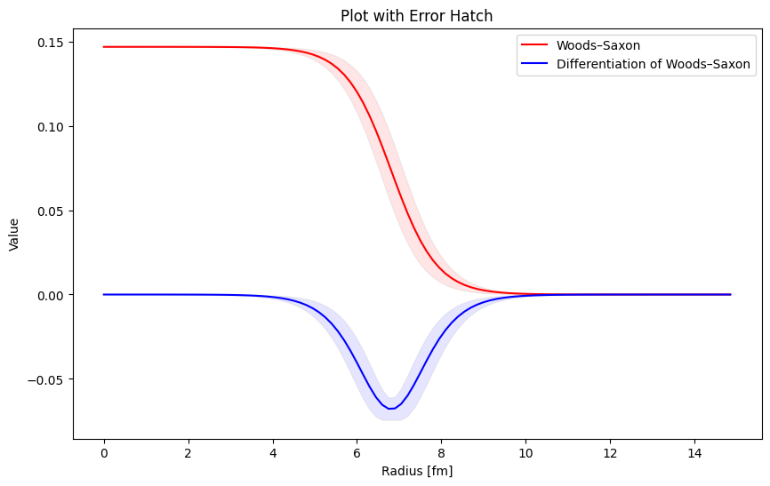

```python
x, y1, y1e, y2, y2e = get_function_value_lists(100)

plt.figure(figsize=(10, 6))

plt.fill_between( x, y1 - y1e, y1 + y1e, color='red', edgecolor='gray', alpha=0.1 )
plt.fill_between( x, y2 - y2e, y2 + y2e, color='blue', edgecolor='gray', alpha=0.1 )
plt.plot(x, y1, color='red', label='Woods–Saxon')
plt.plot(x, y2, color='blue', label='Differentiation of Woods–Saxon')

plt.xlabel('Radius [fm]')
plt.ylabel('Value')
plt.title('Plot with Error Hatch')
plt.legend()
plt.show()
```